# Practice Set p.1

GitHub link: https://github.com/TylerWolfWilliams/GSB-544

```python
import pandas as pd
import numpy as np
import matplotlib.pyplot as plt
from sklearn.pipeline import Pipeline
from sklearn.linear_model import LogisticRegression
from sklearn.discriminant_analysis import LinearDiscriminantAnalysis
from sklearn.svm import SVC
from sklearn.model_selection import GridSearchCV
from sklearn.preprocessing import StandardScaler
```

## The Data

At this link, you will find a dataset containing information about heart disease patients: https://www.dropbox.com/scl/fi/0vrpdnq5asmeulc4gd50y/ha_1.csv?rlkey=ciisalceotl77ffqhqe3kujzv&dl=1

A description of the original dataset can be found here: https://archive.ics.uci.edu/dataset/45/heart+disease (However, this dataset has been cleaned and reduced, and the people have been given fictious names.)

```python
url = "https://www.dropbox.com/scl/fi/0vrpdnq5asmeulc4gd50y/ha_1.csv?rlkey=ciisalceotl77ffqhqe3kujzv&dl=1"
df = pd.read_csv(url)

X = df[['age', 'chol']]
y = (df['diagnosis'] == 'Disease').astype(int)
```

## 1. Logistic Regression

Fit a Logistic Regression using only `age` and `chol` (cholesterol) as predictors.

For a 55 year old, how high would their cholesterol need to be for the doctors to predict heart disease is present?

How high for the doctors to estimate a 90% chance that heart disease is present?

```python
lr_model = LogisticRegression(random_state=42, max_iter=1000)
lr_model.fit(X, y)

# For a 55 year old, find cholesterol for 50% probability
age_55 = 55
chol_lr_50 = -(lr_model.intercept_[0] + lr_model.coef_[0][0] * age_55) / lr_model.coef_[0][1]

# For 90% probability
log_odds_90 = np.log(0.9 / 0.1)
chol_lr_90 = (log_odds_90 - lr_model.intercept_[0] - lr_model.coef_[0][0] * age_55) / lr_model.coef_[0][1]
```

## 2. Linear Discriminant Analysis

Fit an LDA model using only `age` and `chol` (cholesterol) as predictors.

For a 55 year old, how high would their cholesterol need to be for the doctors to predict heart disease is present?

```python
lda_model = LinearDiscriminantAnalysis()
lda_model.fit(X, y)

# For a 55 year old, find cholesterol for 50% probability
chol_lda_50 = -(lda_model.intercept_[0] + lda_model.coef_[0][0] * age_55) / lda_model.coef_[0][1]
```

## 3. Support Vector Classifier

Fit an SVC model using only `age` and `chol` as predictors. Don’t forget to tune the regularization parameter.

For a 55 year old, how high would their cholesterol need to be for the doctors to predict heart disease is present?

```python
svc_pipeline = Pipeline([
    ('scaler', StandardScaler()),
    ('classifier', SVC(kernel='linear', random_state=42))
])

param_grid = {'classifier__C': [0.001, 0.01, 0.1, 1, 10, 100, 1000]}
grid_search = GridSearchCV(svc_pipeline, param_grid, cv=5, scoring='accuracy')
grid_search.fit(X, y)

svc_pipeline = grid_search.best_estimator_
best_C = grid_search.best_params_['classifier__C']

svc_scaler = svc_pipeline.named_steps['scaler']
svc_model = svc_pipeline.named_steps['classifier']

# Convert coefficients back to original scale
w_svc = svc_model.coef_[0]
b_svc = svc_model.intercept_[0]
w_svc_original = w_svc / svc_scaler.scale_
b_svc_original = b_svc - np.dot(w_svc / svc_scaler.scale_, svc_scaler.mean_)

# For a 55 year old, find cholesterol at decision boundary
chol_svc_50 = -(b_svc_original + w_svc_original[0] * age_55) / w_svc_original[1]
```

## 4. Comparing Decision Boundaries

Make a scatterplot of `age` and `chol`, coloring the points by their true disease outcome. Add a line to the plot representing the **linear separator** (aka **decision boundary**) for each of the three models above.

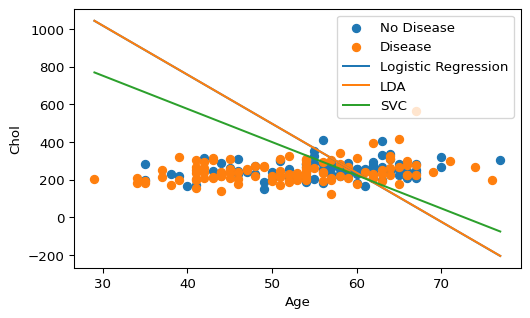

```python
X_arr = np.asarray(X)
y_arr = np.asarray(y)

fig, ax = plt.subplots()

# Scatter of true outcomes (0 = no disease, 1 = disease)
for cls, lbl in zip([0, 1], ["No Disease", "Disease"]):
    m = (y_arr == cls)
    ax.scatter(X_arr[m, 0], X_arr[m, 1], label=lbl)

# Age span for decision boundaries
age_min, age_max = X_arr[:, 0].min(), X_arr[:, 0].max()
age_range = np.array([age_min, age_max])

# Decision boundaries: solve w0*age + w1*chol + b = 0  -> chol = -(b + w0*age)/w1
chol_lr = -(lr_model.intercept_[0] + lr_model.coef_[0, 0] * age_range) / lr_model.coef_[0, 1]
chol_lda = -(lda_model.intercept_[0] + lda_model.coef_[0, 0] * age_range) / lda_model.coef_[0, 1]
chol_svc = -(b_svc_original + w_svc_original[0] * age_range) / w_svc_original[1]

ax.plot(age_range, chol_lr, label="Logistic Regression")
ax.plot(age_range, chol_lda, label="LDA")
ax.plot(age_range, chol_svc, label="SVC")

ax.set_xlabel("Age")
ax.set_ylabel("Chol")
ax.legend()
plt.show()
```